# Methods 3, Week 3:

About the course

Maxime Sainte-Marie

# Assignment Assessment

[interactive chart not shown]

# Hypothesis Testing

[interactive chart not shown]

## What does ChatGPT think about this?

[figure not shown]

## Fischer’s Test of Significance

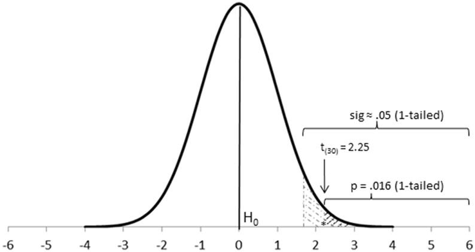

## Neyman-Pearson’s Hypothesis Testing

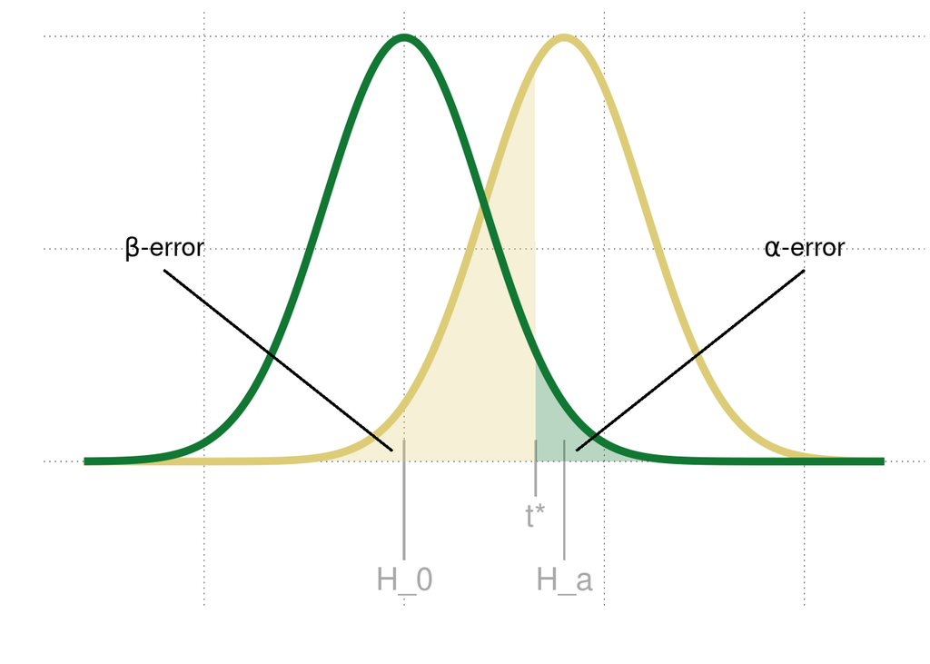

## Null Hypothesis Significance Testing (NHST)

- A patchwork of fundamentally different hypothesis testing models
  - $p$, $H_0$, $H_A$, $\alpha$, $\beta$, $1- \beta$ presented as belonging to a single, coherent theory of statistical inference
  - quasi-Bayesian interpretation of results
- A mindless Ritual
  1. Set up a statistical null hypothesis of “no difference or correlation”. Don’t specify hypotheses’ predictions
  2. Use 5% as a convention for rejecting the null. If significant, accept your research hypothesis. Report the result as $\;p<0.05$, $\;p<0.01$ or $\;p<0.001$ (whichever comes next the obtained $p$-value)

## What do you think is wrong with NHST?

[interactive chart not shown]

## What is wrong with NHST?

- Binary Scope
- P-value Misinterpretation
- Multiple Testing
- Sample Size
- Effect Size Neglect
- Publication Bias
- Choice of Null Hypothesis
- Assumptions Violation
- Research integrity: P-hacking, HARKing, Replicability…

# Statistics beyond NHST

- Given the limitations of hypothesis testing as implemented through Fisher’s significance testing, Neyman-Pearson’s acceptance testing and NHST in general…
  - … the main objective of this course is to present you different ways to overcome these limitations
- Methods
  - Bayesian Analysis
  - Multilevel Linear Model
  - Meta-analyses
  - Machine Learning

## Bayesian Analysis

- Statistical Learning process that uses Bayes’ theorem to update beliefs or make predictions about uncertain parameter values based on observed data
  - Richer characterization of uncertainty
  - Incorporation of prior information
  - Probabilistic statements about parameters of interest
- Challenges
  - Prior elicitation can be a subjective process
  - Tractability issues and posterior approximation challenges

## Multilevel modeling (MLM)

- Statistical method that investigates variations and relationships between variables of interest by taking into account population structure and dependencies
- Focus on estimations, effect size and variability
  - Fixed and random effects
- Greater interpretability
  - Instead of just knowing if an effect is significant or not, researchers can understand how much variability is explained at different levels and how predictors relate to the outcome on average.

## Meta-Analysis

- Statistical technique used in research to combine and analyze the results from multiple independent studies on a particular topic or research question
  - Aims to provide a quantitative summary of the findings from various individual studies
  - Allows for more robust and reliable conclusions to be drawn compared to what could be achieved from any single study

## Machine Learning (ML)

- Machine learning is a subfield of artificial intelligence (AI) that focuses on the development of algorithms and statistical models that enable computer systems to improve their performance on a specific task through (supervised or supervised) learning from data, without being explicitly programmed.
- Relation to hypothesis testing?
  - Feature selection for hypothesis formulation
  - Hypothesis testing can be framed as a classification problem
  - A/B testing
  - Anomaly detection, sample size estimation…

# Interlude

How does this relate to set theory?

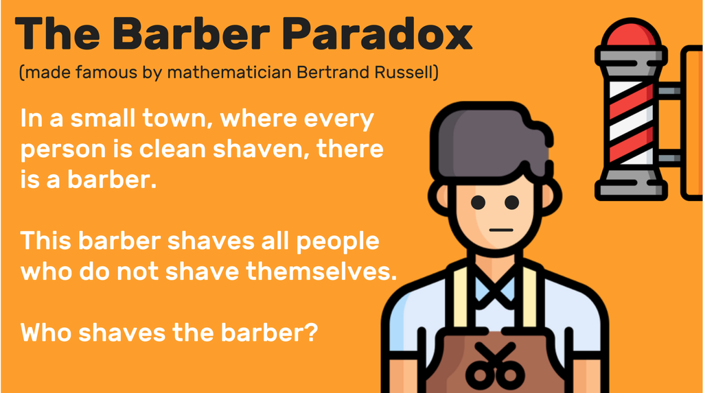